# resource shock detection

June, 2024

Input on this methods from: Malin Pinsky, Thomas Frölicher

Coding: Aurore Maureaud

## Data

Example data picked for this test: agriculture sector, CROVER crop model, GFDL-ESM4 climate model, SSP585 climate experiment, and 4 agricultural crops: maize, wheat, soybean, rice.

For each method used, the residuals of the method are computed and z-scored, and shocks are identified as crop yields exceeding 2SD from the mean (below -2 and above 2 or the z-scored residuals).

## Detecting annual resource shocks

### Detrending with linear models

This method is most straightforward used in [Fredston et al., 2023](https://www.nature.com/articles/s41586-023-06449-y) but does not work well for non-linear trends (which is most cases in long-term data from ISIMIP). In the example shown below, on the maize crop data seems to be properly detrended by the linear model. This is also evident from the R-square of the model (95% for maize, and <50% for other crops).

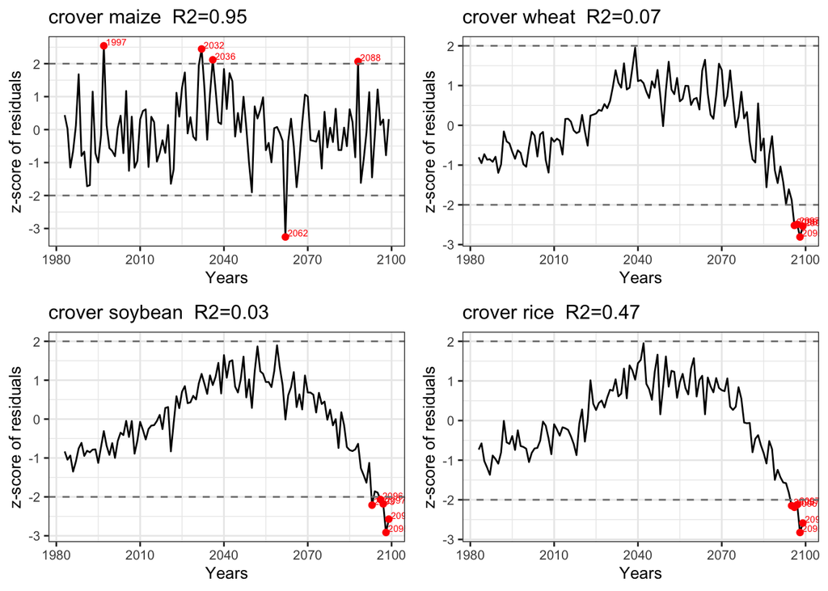

### 31-year moving average

A 31-year average works well but it might not apply to the entire time-series of the dataset. The rolling window of 31 is chosen as it eliminates most of the interannual (e.g., ENSO, NAO, etc) and decadal variability (PDO) in the climate/ocean system (it is also often used in IPCC assessments).

The rollmean() function from the `zoo` R package is used, where the k rolling window parameter needs to be chosen.

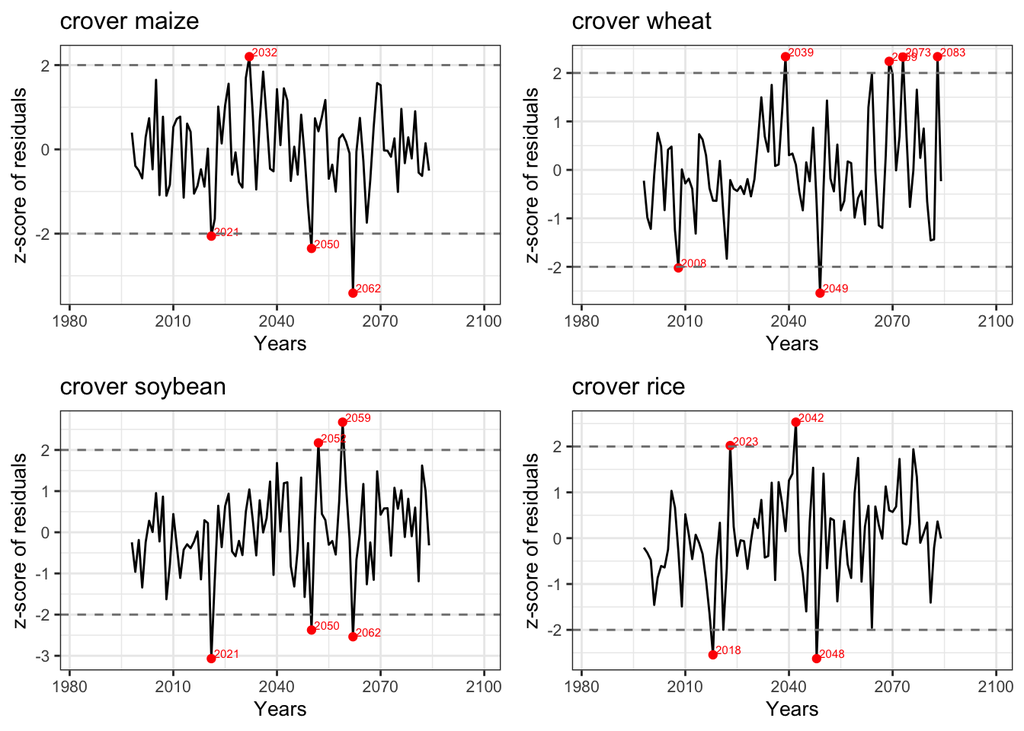

An extrapolation of the time-series could be considered, as done in a previous [publication](https://doi.org/10.5194/egusphere-2024-488): “The past anthropogenic warming is here estimated by applying a 31-year running mean with a linear extrapolation for the last 15 years, assuming constant warming rate based on the last 31 years.”

### Savitzky-Golay

A Savitzky-Golay low-pass filter (e.g., as in [this paper](https://doi.org/10.1016/j.sigpro.2005.02.002)) can detrend the data to isolate shocks.

- See brief description of low-pass filters [here](https://se.mathworks.com/discovery/low-pass-filter.html).
- See brief description of Savitzky-Golay filters [here](https://se.mathworks.com/help/signal/ref/sgolayfilt.html).

The savgol() function from the `pracma` R package is used, where the derivative order parameter *dorder* is set to 0 for smoothing, the filter order parameter *forder* is set to 4 for a quartic filter, and the filter length parameter *fl* is set at 11.

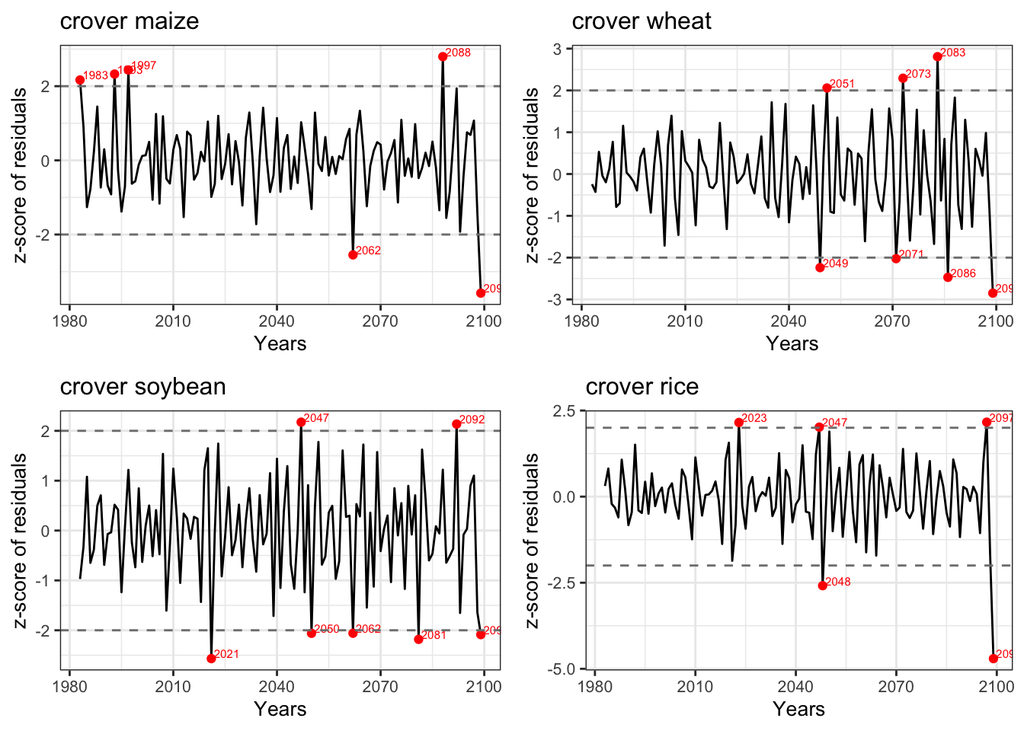

#### Sensitivity to filter length

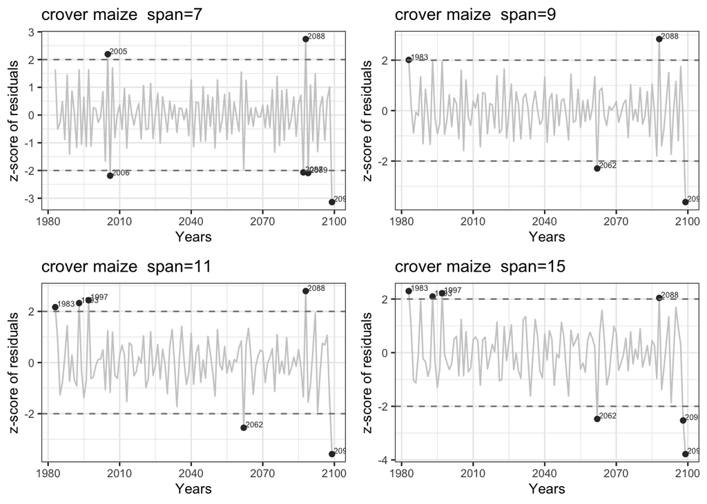

#### Sensitivity to the filter order and length

Filter is either quadratic (2), or quartic (4), and filter length is either set a 7 or 11.

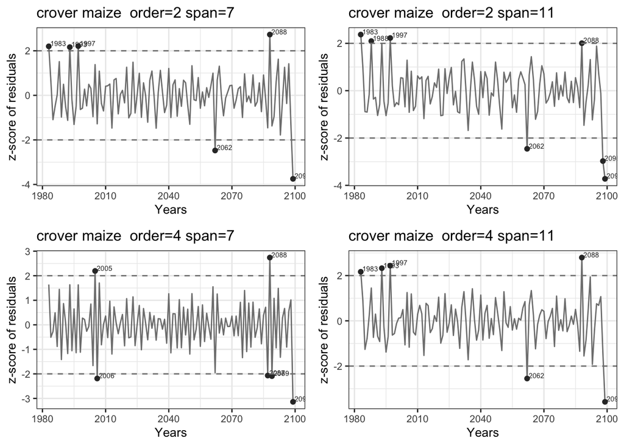

### Smoother across crops

The loess() function from the `stats` R package is used, where the parameter controlling the degree of smoothing span is set at 1, and the degree of the polynomial is 2.

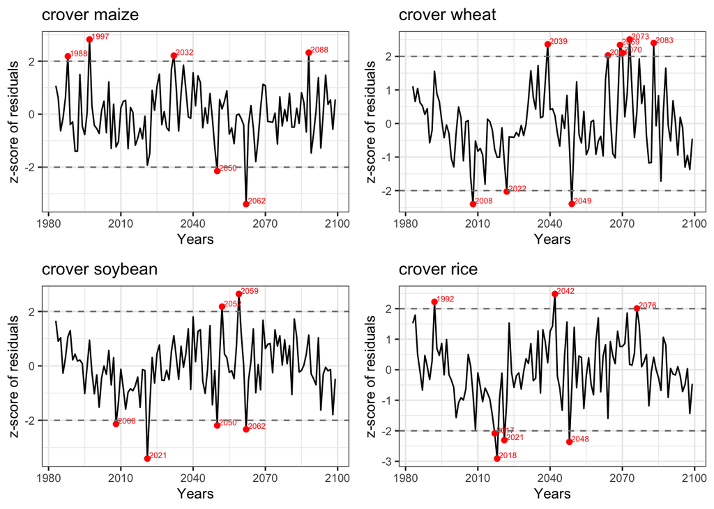

#### Sensitivity to smoother span

Testing the sensitivity of the shock detection to the smoother span, we can see that for the maize model example, we detect 5, 6, or 7 shocks for a span from 0.5 to 1.5.

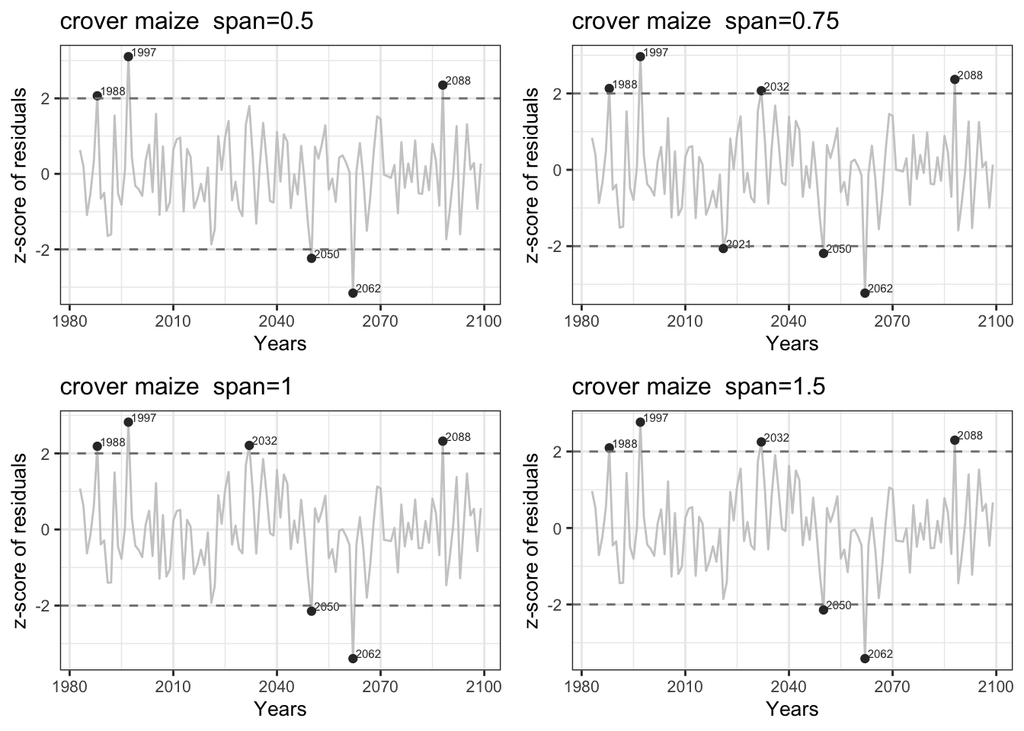

#### Sensitivity to smoother span and degree

Sensitivity to the smoother span and polynomial degree.

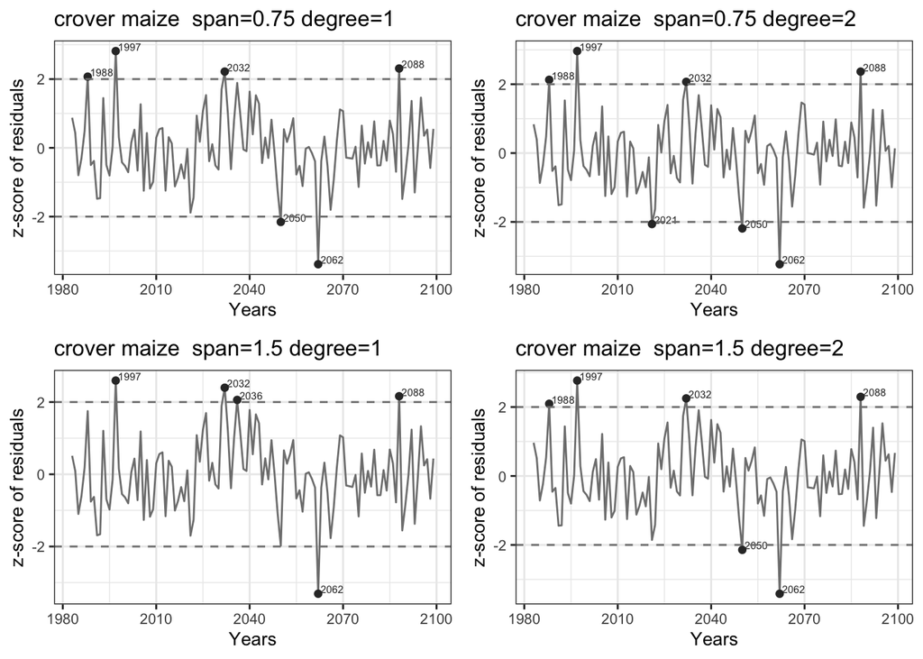